# BigBasket Products and Price Analysis

Anirudha Gajula

2022-7-11

# Introduction of The Company and Dataset

BigBasket is an online food and grocery store that delivers personal and household needs right to the customer’s doorstep. It was founded on October 1st, 2011 by a group of people (Abhinay Choudhari, Hari Menon, Vipul Parekh, VS Ramesh, and VS Sudhakar).

The brand is expanding well. It has raised an estimated $1.3B in over 19 rounds. Its most recent funding was raised on June 2nd, 2022 in an undisclosed round. It has notable investors partnering with it’s growth too. Such as, Alibaba Group, CDC Group and so on.

Dataset relating to the company’s products and prices has been downloaded from Kaggle.com. It contains the entire catalog of products listed on the e-commerce giant’s website (~ 28K). The dataset contains a **usability score** of 10 and carries a **Creative Commons License** (CC BY-NC-SA 4.0). The usability score determines how well documented and usable the dataset is, according to set parameters. The license on the other hand, dictates the terms of usage for the dataset.

In addition to the product listing, it also lists the sale price, market price, category, sub-category and description of each product. All of the rows are indexed to an index column (makes it easier to identify rows).

# Data Cleaning and Exploration

Let’s face it. Data is *mostly* unclean majority of the time. Do not be fooled by the usability score. It only determines how **well documented** the dataset is. That is, data validation could be perfect; column names are concise and descriptive; Data is formatted properly; Metadata is extensive and so on. However, it does not guarantee against presence of NA values (missing data).

This dataset in particular had NA values consisting of more than 30 percent when combining NA counts from all the columns. See below:

```
##        index      product     category sub_category        brand   sale_price
##            0            1            0            0            1            0
## market_price         type       rating  description
##            0            0         8626          115
```

In the tibble above, NA value counts of each column is listed. Rating has quite a bit of NAs followed by Description column. 8626 NA values to be exact. That amounts to a rounded estimate of 31.3 percent of all values in the column. Which inevitably affects all the rows in the data frame.

Where are these 30 percent of NA values coming from? Let’s find out

```
##                    category rating
## 1                 Baby Care    114
## 2     Bakery, Cakes & Dairy    186
## 3          Beauty & Hygiene   2403
## 4                 Beverages    251
## 5      Cleaning & Household    575
## 6         Eggs, Meat & Fish    350
## 7  Foodgrains, Oil & Masala    483
## 8       Fruits & Vegetables    557
## 9      Gourmet & World Food   2291
## 10   Kitchen, Garden & Pets   1071
## 11   Snacks & Branded Foods    345
```

Beauty and Hygiene have the most NA values followed by Gourmet & World Food. While Baby Care has the least NA values. t raises the question of how people are rating the products. To be more precise, Who are buying the products? parents? People who are part of a family? More data is needed to conduct further analysis in this aspect.

You cannot be satisfied with just identifying NA values. You need to check for duplicates and incorrect format as well. See below:

```
## [1] 0
```

No duplicates were detected when passing the index column through a duplicated function. How about a different approach?

```
## character(0)
```

The dataset was converted to a list and passed through a base function duplicated() as it utilizes vectors. The output lists columns that have duplicated values. No duplicates exist.

How about getting a glimpse to see how data is formatted in the columns?

```
## Rows: 27,555
## Columns: 10
## $ index        <dbl> 1, 2, 3, 4, 5, 6, 7, 8, 9, 10, 11, 12, 13, 14, 15, 16, 17…
## $ product      <chr> "Garlic Oil - Vegetarian Capsule 500 mg", "Water Bottle -…
## $ category     <chr> "Beauty & Hygiene", "Kitchen, Garden & Pets", "Cleaning &…
## $ sub_category <chr> "Hair Care", "Storage & Accessories", "Pooja Needs", "Bin…
## $ brand        <chr> "Sri Sri Ayurveda", "Mastercook", "Trm", "Nakoda", "Nivea…
## $ sale_price   <dbl> 220.00, 180.00, 119.00, 149.00, 162.00, 169.00, 58.00, 25…
## $ market_price <dbl> 220, 180, 250, 176, 162, 199, 58, 250, 1098, 20, 290, 600…
## $ type         <chr> "Hair Oil & Serum", "Water & Fridge Bottles", "Lamp & Lam…
## $ rating       <dbl> 4.1, 2.3, 3.4, 3.7, 4.4, 3.3, 3.6, 4.0, 3.5, 4.3, 4.0, 2.…
## $ description  <chr> "This Product contains Garlic Oil that is known to help p…
```

If you notice, market price does not display decimal points. Let’s fix that shall we?

```
## # A tibble: 10 × 10
##    index product       category sub_category brand sale_price market_price type
##    <dbl> <chr>         <chr>    <chr>        <chr>      <dbl>        <dbl> <chr>
##  1     1 Garlic Oil -… Beauty … Hair Care    Sri …        220          220 Hair…
##  2     2 Water Bottle… Kitchen… Storage & A… Mast…        180          180 Wate…
##  3     3 Brass Angle … Cleanin… Pooja Needs  Trm          119          250 Lamp…
##  4     4 Cereal Flip … Cleanin… Bins & Bath… Nako…        149          176 Laun…
##  5     5 Creme Soft S… Beauty … Bath & Hand… Nivea        162          162 Bath…
##  6     6 Germ - Remov… Cleanin… All Purpose… Natu…        169          199 Disi…
##  7     7 Multani Mati  Beauty … Skin Care    Sati…         58           58 Face…
##  8     8 Hand Sanitiz… Beauty … Bath & Hand… Bion…        250          250 Hand…
##  9     9 Biotin & Col… Beauty … Hair Care    StBo…       1098         1098 Sham…
## 10    10 Scrub Pad - … Cleanin… Mops, Brush… Scot…         20           20 Uten…
## # … with 2 more variables: rating <dbl>, description <chr>
```

After passing the sale price column through a formattable function from the formattable package and modifying a few parameters, market price column is now consistent with how sale price is displayed.

Cleaning is not done yet. Where is the data located? Any discrepancies? Let’s check:

```
##      index         product            category         sub_category
##  Min.   :    1   Length:27555       Length:27555       Length:27555
##  1st Qu.: 6890   Class :character   Class :character   Class :character
##  Median :13778   Mode  :character   Mode  :character   Mode  :character
##  Mean   :13778
##  3rd Qu.:20666
##  Max.   :27555
##
##     brand             sale_price        market_price         type
##  Length:27555       Min.   :    2.45   Min.   :    3.0   Length:27555
##  Class :character   1st Qu.:   95.00   1st Qu.:  100.0   Class :character
##  Mode  :character   Median :  190.00   Median :  220.0   Mode  :character
##                     Mean   :  322.51   Mean   :  382.1
##                     3rd Qu.:  359.00   3rd Qu.:  425.0
##                     Max.   :12500.00   Max.   :12500.0
##
##      rating      description
##  Min.   :1.000   Length:27555
##  1st Qu.:3.700   Class :character
##  Median :4.100   Mode  :character
##  Mean   :3.943
##  3rd Qu.:4.300
##  Max.   :5.000
##  NA's   :8626
```

No surprises in the data. Prices are where they are expected to be. No weird values (like -5 or 1,000,000). Rating is normal. Values don’t go beyond the minimum and maximum limits. Same goes for Index too. All the columns are in the right classes.

Since the next step is dealing with NA values in the Rating column, Let’s quickly verifying how rating relates to the different types of prices and check its own distribution as well.

Firstly, Rating against Sale Price

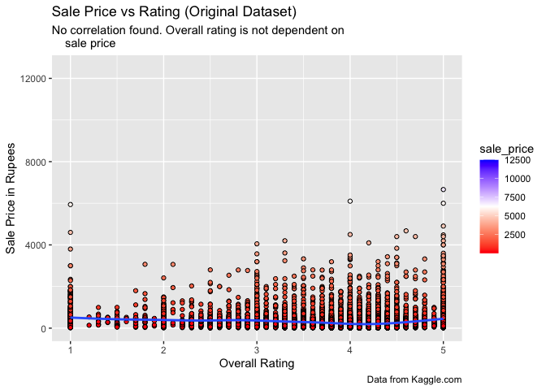

Next, Rating against Market Price:

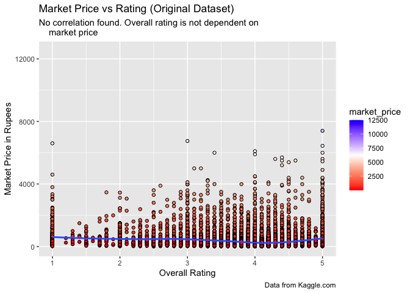

Both the graphs show that rating has no correlation with either Market Price or Sale Price. Yes, there are slight changes in data points themselves, but no correlation nonetheless.

Can’t forget about Rating column’s distribution:

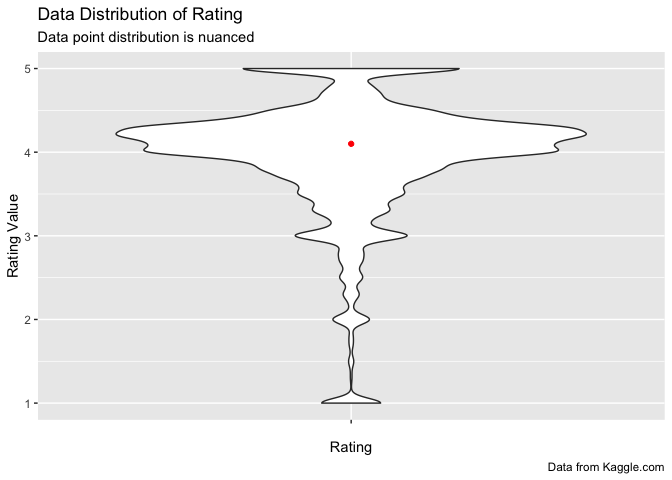

Data is mostly clustered around the median (red dot) between 4 - 4.5. There are also smaller individual clusters around whole numbers across the spectrum.

Let us also verify how average overall rating distributes across categories.

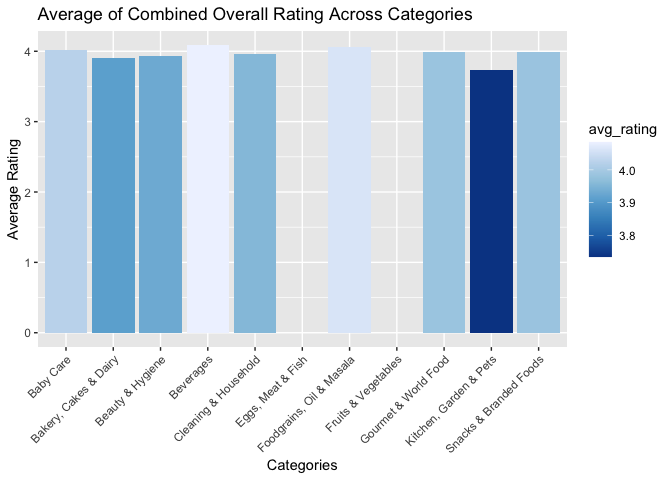

Checking all of these relationships is important. Because NA values will be filled due to the proportion of missing data being heavily significant. If data changes, verifying original data relationships against new ones will help us quickly identify unfavorable changes.

However, before filling in NA values, we must identify the pattern of Missing Data. Is it Missing Completely At Random (MCAR)? Missing At Random (MAR)?, Missing Not At Random (MNAR)?